# Coding for Random Adventures

Brian

2/25/2023

# Dirty Devil River

#### NWIS data

```r
q <- readNWISdv(siteNumbers = '09333500',
                parameterCd = '00060',
                startDate = '2002-01-01',
                endDate = '2022-03-20') %>%
  rename(q = 'X_00060_00003') %>%
  select(-X_00060_00003_cd)
```

#### Discharge, 2002-2022

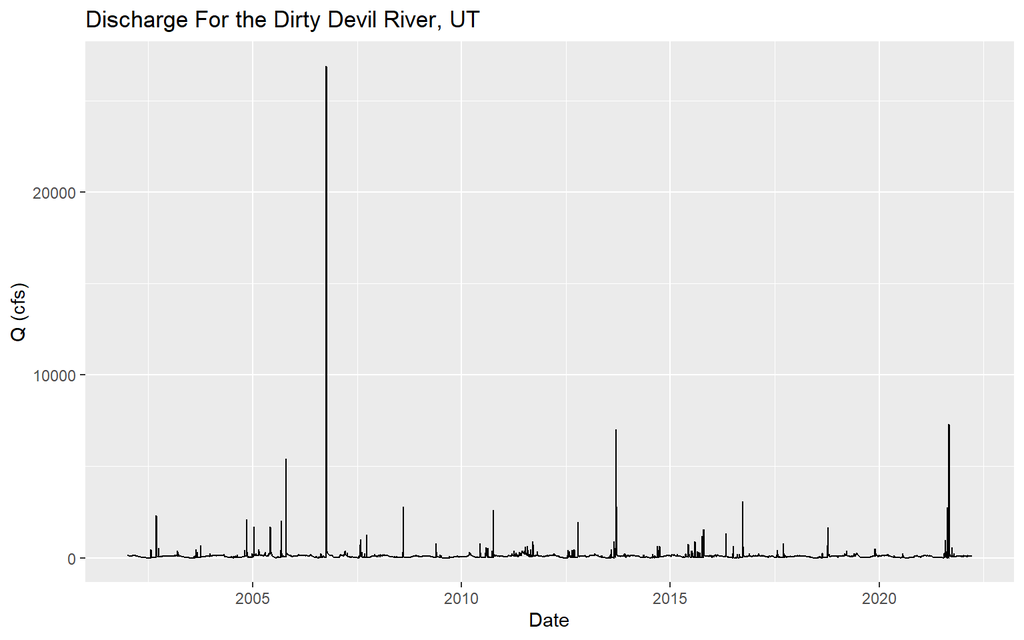

```r
ggplot(q, aes(x = Date, y = q)) +
  geom_line() +
  ylab('Q (cfs)') +
  ggtitle('Discharge For the Dirty Devil River, UT')
```

#### Interactive Data Plotter

```r
q_xts <- xts(q$q, order.by = q$Date)
dygraph(q_xts) %>%
  dyAxis("y", label = "Discharge (cfs)")
```

[interactive chart not shown]

#### March Discharge

```r
q_march <- q %>%
  addWaterYear() %>%
  group_by(waterYear)%>%
  mutate(waterDay = (as.integer(difftime(Date, ymd(paste0(waterYear - 1 ,'-09-30')), units = "days")))) %>% filter(waterDay >= 162, waterDay <= 168) %>%
  group_by(waterDay) %>%
  mutate(avg = mean(q))
```

#### March Discharge, 2002-2022

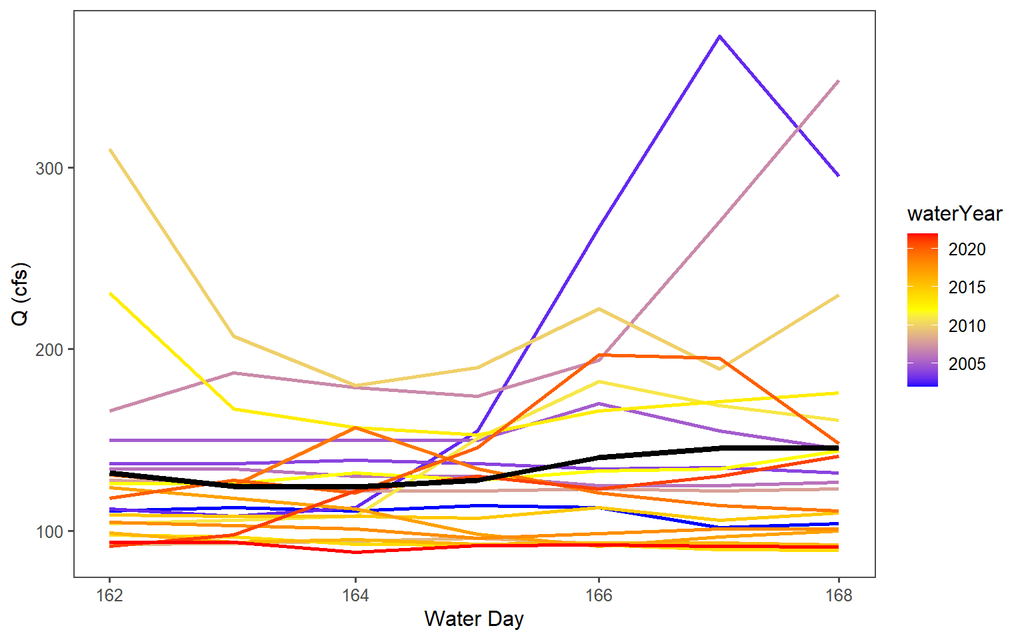

```r
ggplot(q_march) +
  geom_line(mapping = aes(x = waterDay, q, color=waterYear, group=waterYear), size = 1)+
  geom_line(mapping = aes(x = waterDay, y = avg), size = 1.5)+
  #geom_smooth(method = lm) +
  scale_x_log10() +
  theme_few() +
  scale_colour_gradient2(low = "blue", mid = "yellow" , high = "red",
                         midpoint=2012)+
  ylab('Q (cfs)')+
  xlab('Water Day')
```

**Discharge (cfs) for 2002-2022 for March 11-17. Average discharge is the black line.**

# Kokopelli SNOTEL stations

SNOTEL station 572 in the La Sal mountains

```
SNOTEL_MOAB_area <- snotel_download(site_id = c(1215, 572), path = tempdir('../data'), internal = TRUE)

write.csv(SNOTEL_MOAB_area,"C:/Users/13074/Documents/ESS580/thesis_project/the_Dirty_Devil/data/snotel_MOAB.csv", row.names = FALSE) #write in the raw data
```

```r
SNOTEL_MOAB_area <- read.csv("C:/Users/13074/Documents/ESS580/thesis_project/the_Dirty_Devil/data/snotel_MOAB.csv", header = TRUE)
```

```r
SNOTEL_MOAB_area$Date <- as.Date(SNOTEL_MOAB_area$date)

str(SNOTEL_MOAB_area)
```

```
## 'data.frame':    19353 obs. of  19 variables:
##  $ network                 : chr  "SNTL" "SNTL" "SNTL" "SNTL" ...
##  $ state                   : chr  "UT" "UT" "UT" "UT" ...
##  $ site_name               : chr  "lasal mountain-lower " "lasal mountain-lower " "lasal mountain-lower " "lasal mountain-lower " ...
##  $ description             : chr  "Horse Creek-Mill Creek (140300050404)" "Horse Creek-Mill Creek (140300050404)" "Horse Creek-Mill Creek (140300050404)" "Horse Creek-Mill Creek (140300050404)" ...
##  $ start                   : chr  "2012-10-01" "2012-10-01" "2012-10-01" "2012-10-01" ...
##  $ end                     : chr  "2023-03-29" "2023-03-29" "2023-03-29" "2023-03-29" ...
##  $ latitude                : num  38.5 38.5 38.5 38.5 38.5 ...
##  $ longitude               : num  -109 -109 -109 -109 -109 ...
##  $ elev                    : int  2677 2677 2677 2677 2677 2677 2677 2677 2677 2677 ...
##  $ county                  : chr  "San Juan" "San Juan" "San Juan" "San Juan" ...
##  $ site_id                 : int  1215 1215 1215 1215 1215 1215 1215 1215 1215 1215 ...
##  $ date                    : chr  "2012-10-01" "2012-10-02" "2012-10-03" "2012-10-04" ...
##  $ snow_water_equivalent   : num  0 0 0 0 0 0 0 0 0 0 ...
##  $ precipitation_cumulative: num  0 0 0 0 0 0 0 0 0 0 ...
##  $ temperature_max         : num  17.9 18.8 19.2 17.8 14.6 10.8 10.5 13.8 15 17 ...
##  $ temperature_min         : num  8.3 7.4 8.4 8.3 6.3 1 -0.3 1.9 4.2 6.5 ...
##  $ temperature_mean        : num  12.3 12.1 12.9 12.7 9.9 6.2 4.2 7.8 8.6 10.9 ...
##  $ precipitation           : num  0 0 0 0 0 0 0 0 0 0 ...
##  $ Date                    : Date, format: "2012-10-01" "2012-10-02" ...
```

```r
SNOTEL_MOAB_area_clean <- SNOTEL_MOAB_area %>% # filter for the timeframe
  addWaterYear() %>%
  mutate(daymonth = format(as.Date(Date), "%d-%m")) %>%
  na.omit()


SNOTEL_MOAB_area_clean <- SNOTEL_MOAB_area_clean %>%
  group_by(waterYear)%>%
  mutate(waterDay = (as.integer(difftime(Date, ymd(paste0(waterYear - 1 ,'-09-30')), units = "days"))))

may_moab_572 <- SNOTEL_MOAB_area_clean %>%
  filter(site_id == 572) %>%
  filter(waterDay >= 220 & waterDay <= 243)

#str(may_moab_572)
```

### SWE

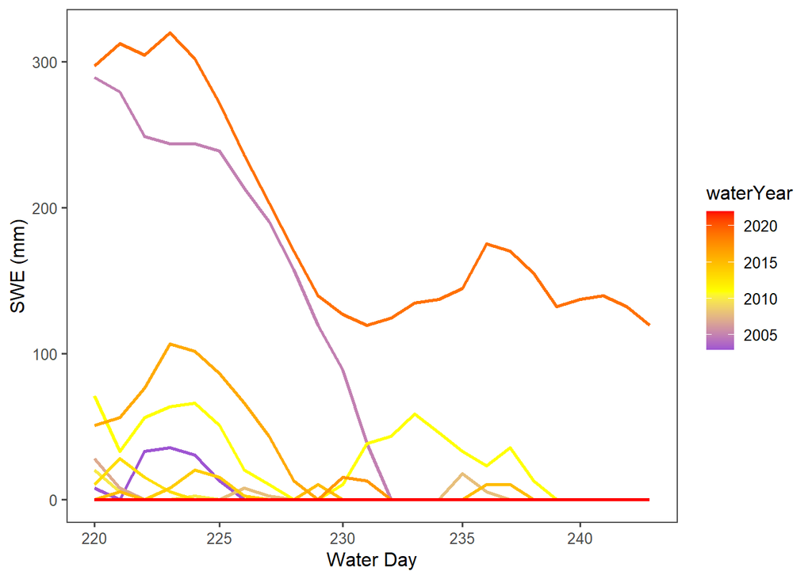

```r
ggplot(may_moab_572) +
  geom_line(mapping = aes(x = waterDay, y=snow_water_equivalent, color=waterYear, group=waterYear), size = 1)+
  scale_x_log10() +
  theme_few() +
  scale_colour_gradient2(low = "blue", mid = "yellow" , high = "red",
                         midpoint=2011)+
  ylab('SWE (mm)')+
  xlab('Water Day')
```

### Temperature

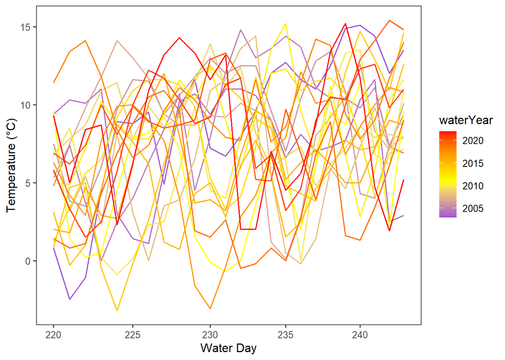

```r
ggplot(may_moab_572) +
  geom_line(mapping = aes(x = waterDay, y= temperature_mean, color=waterYear, group=waterYear), size = .7)+
  scale_x_log10() +
  theme_few() +
  scale_colour_gradient2(low = "blue", mid = "yellow" , high = "red",
                         midpoint=2011)+
  ylab('Temperature (°C)')+
  xlab('Water Day')
```

### Precipitation

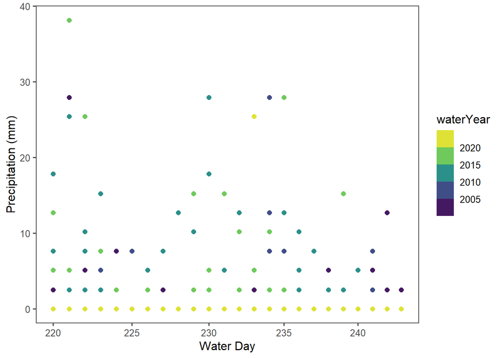

```r
ggplot(may_moab_572) +
  geom_point(mapping = aes(x = waterDay, y= precipitation, color=waterYear, group=waterYear), size = 2)+
  scale_x_log10() +
  theme_few() +
  scale_color_viridis_b() +
  ylab('Precipitation (mm)')+
  xlab('Water Day')
```

# Fort Collins Weirdness

*Checking to see whether Fort Collins has been increasing or decreasing in daily temperature variability over the last ~42 years.*

```r
CO3005_CO3006 <- read.csv("C:/Users/13074/Downloads/CO3005_CO3006.txt", comment.char="#")
```

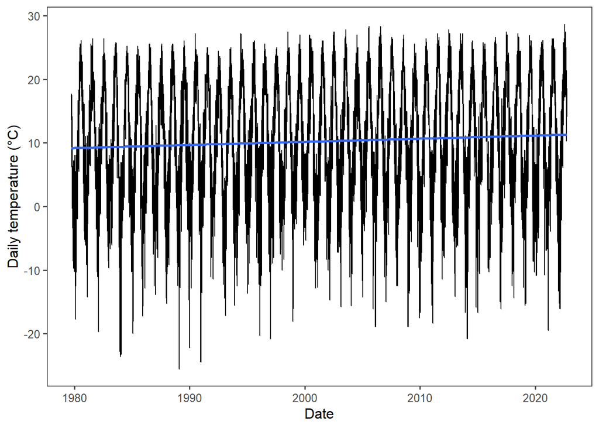

```r
CO3005_CO3006$Date <- ymd(CO3005_CO3006$day)

COOP_stations_clean <- CO3005_CO3006 %>% # filter for the timeframe
  filter(station == "CO3005") %>%
  addWaterYear() %>%
  mutate(daymonth = format(as.Date(Date), "%d-%m")) %>%
  group_by(waterYear)%>%
  mutate(waterDay = (as.integer(difftime(Date, ymd(paste0(waterYear - 1 ,'-09-30')), units = "days")))) %>%   na.omit()

COOP_stations_clean <- COOP_stations_clean %>%
  mutate(avg_T_c = (highc+lowc)/2) %>%
  filter(waterYear >= 1980 & waterYear <= 2022)


write.csv(COOP_stations_clean,"C:/Users/13074/Documents/ESS580/thesis_project/the_Dirty_Devil/data/FC_COOP_stations_clean.csv", row.names = FALSE)

ggplot(COOP_stations_clean, aes(x = Date, y = avg_T_c)) + #, color = station_name)) +
  geom_line() + #lwd = 2) +
  theme_few() +
  geom_smooth(method = "lm", se=FALSE) +
  ylab('Daily temperature (°C)') +
  xlab('Date')
```

Looking at whether there is a increase or decrease in daily temperature variability, 1980 to 2022

```r
#average water year temperature
CO3005_yearly_wy_aver <- COOP_stations_clean %>%
  filter(station == "CO3005") %>%
  group_by(waterYear) %>%
  filter(waterYear >= 1980) %>%
  mutate(aver_ann_temp = mean(avg_T_c))
```

```r
#Average temperature by day for all water years:
CO3005_daily_wy_aver <- CO3005_yearly_wy_aver %>%
  group_by(daymonth) %>%
  mutate(aver_day_temp = mean(avg_T_c))
#average mean temperature by day for the period of record:
CO3005_daily_wy_aver <- CO3005_daily_wy_aver %>%
  group_by(daymonth) %>%
  mutate(all_ave_temp = mean(CO3005_daily_wy_aver$aver_day_temp))
#str(CO3005_daily_wy_aver)
```

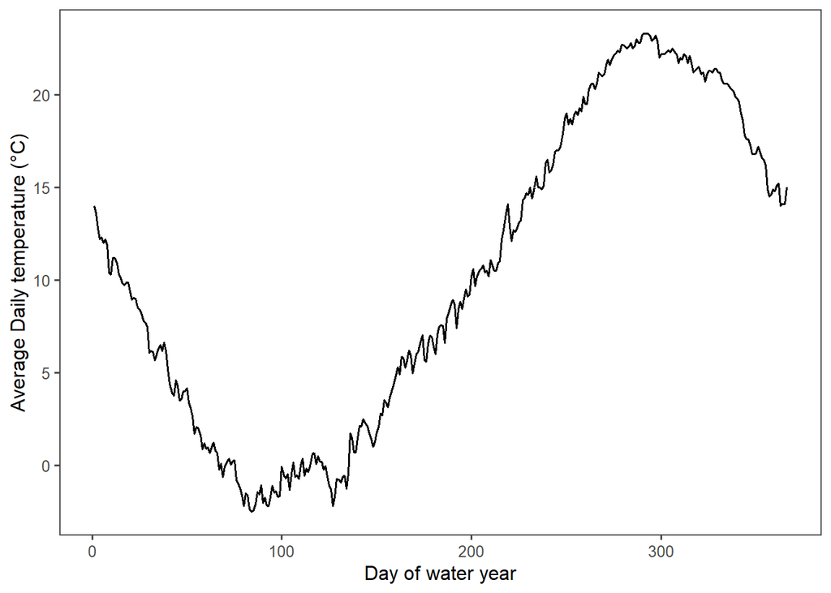

```r
# try to show all years as means.
CO3005_daily_wy_aver2 <- CO3005_daily_wy_aver %>%
  #filter(waterYear == "1987" | waterYear == "2021") %>%
  group_by(waterDay) %>%
  mutate(date_temp = mean(avg_T_c))

CO3005_daily_wy_aver2$date_temp <- signif(CO3005_daily_wy_aver2$date_temp,3) #reduce the sig figs
ggplot(CO3005_daily_wy_aver2, aes(x = waterDay, y = date_temp))+#, color = waterYear)) +
  geom_line(size= 0.7) +
  #geom_line(aes) +
  theme_few() +
  #geom_smooth(method = "lm", se=FALSE) +
  ylab('Average Daily temperature (°C)') +
  xlab('Day of water year')
```

Standard deviation- Determining residuals

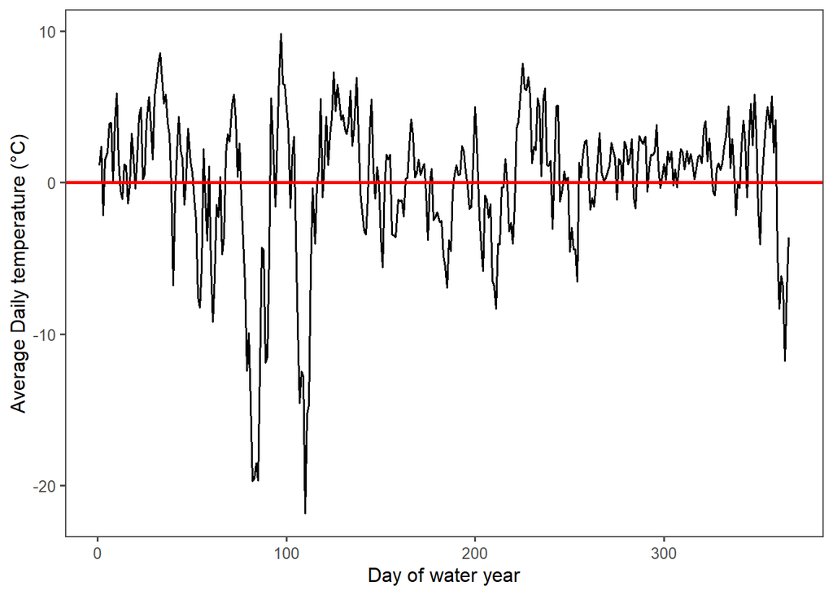

```r
CO3005_standard_dev <- CO3005_daily_wy_aver %>%
  group_by(waterYear) %>%
  mutate(residual = (all_ave_temp-aver_ann_temp)+avg_T_c-aver_day_temp) %>%
  mutate(deviation = abs(residual-lag(residual)))
#checking the detrend
detrend <- CO3005_standard_dev %>%
  filter(waterYear == 1984)

ggplot(detrend, aes(x = waterDay, y = residual))+#, color = waterYear)) +
  geom_line(size= 0.7) +
  geom_hline(yintercept=0, color = "red", size = 1) +
  theme_few() +
  #geom_smooth(method = "lm", se=FALSE) +
  ylab('Average Daily temperature (°C)') +
  xlab('Day of water year')
```

```r
mean(CO3005_standard_dev$residual)
```

```
## [1] 6.628865e-17
```

*The mean of the residuals is close enough to zero*

Calculating standard deviation for the timeseries

```r
CO3005_standard_dev_all <- CO3005_standard_dev %>%
  group_by(waterYear) %>%
  mutate(nmbr = n())
CO3005_standard_dev_all <- CO3005_standard_dev_all %>%
  group_by(waterYear) %>%
  mutate(resid_mean = mean(residual)) %>%
  mutate(sd_1 = residual-resid_mean) %>%
  mutate(sd_2 = (((sum((sd_1)^2))/((nmbr-1))))^(0.5)) %>%
  distinct(sd_2, .keep_all = TRUE) %>%
   select(waterYear, sd_2)
CO3005_standard_dev_all %>%
  kable(.,'html') %>%
  kable_styling() %>%
  scroll_box(width='250px',height='500px')
```

| waterYear | sd_2 |
| --- | --- |
| 1980 | 4.337432 |
| 1981 | 3.973745 |
| 1982 | 4.222411 |
| 1983 | 4.128891 |
| 1984 | 4.767288 |
| 1985 | 4.494363 |
| 1986 | 4.724432 |
| 1987 | 4.137025 |
| 1988 | 4.200725 |
| 1989 | 4.851350 |
| 1990 | 4.337152 |
| 1991 | 4.444639 |
| 1992 | 4.051157 |
| 1993 | 3.908436 |
| 1994 | 3.974091 |
| 1995 | 4.568431 |
| 1996 | 4.775703 |
| 1997 | 4.401586 |
| 1998 | 3.896827 |
| 1999 | 4.233785 |
| 2000 | 3.775958 |
| 2001 | 3.853596 |
| 2002 | 3.865101 |
| 2003 | 4.223444 |
| 2004 | 4.173821 |
| 2005 | 3.736288 |
| 2006 | 4.613398 |
| 2007 | 4.088750 |
| 2008 | 3.744253 |
| 2009 | 4.304619 |
| 2010 | 4.070335 |
| 2011 | 3.912852 |
| 2012 | 3.688620 |
| 2013 | 4.393656 |
| 2014 | 4.500779 |
| 2015 | 4.757422 |
| 2016 | 3.750038 |
| 2017 | 4.506299 |
| 2018 | 4.000405 |
| 2019 | 4.314882 |
| 2020 | 4.274963 |
| 2021 | 4.549357 |
| 2022 | 4.379053 |

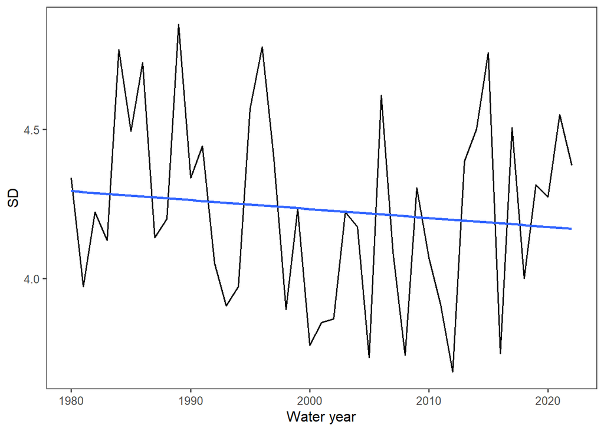

```r
#CALLING THIS something different
CO3005_all_V2 <- ggplot(CO3005_standard_dev_all, aes(x = waterYear, y = sd_2))+
  geom_line(size= 0.7) +
  theme_few() +
  geom_smooth(method = "lm", se=FALSE) +
  ylab('SD') +
  xlab('Water year')
print(CO3005_all_V2)
```

```r
CO3005_sd_mk <- mk.test(CO3005_standard_dev_all$sd_2)
print(CO3005_sd_mk)
```

```
##
##  Mann-Kendall trend test
##
## data:  CO3005_standard_dev_all$sd_2
## z = -0.64886, n = 43, p-value = 0.5164
## alternative hypothesis: true S is not equal to 0
## sample estimates:
##             S          varS           tau
##  -63.00000000 9130.33333333   -0.06976744
```

```r
CO3005_sd_sens <- sens.slope(CO3005_standard_dev_all$sd_2)
print(CO3005_sd_sens)
```

```
##
##  Sen's slope
##
## data:  CO3005_standard_dev_all$sd_2
## z = -0.64886, n = 43, p-value = 0.5164
## alternative hypothesis: true z is not equal to 0
## 95 percent confidence interval:
##  -0.012925881  0.005714914
## sample estimates:
##  Sen's slope
## -0.003602265
```

Summer temperature standard deviation

```r
CO3005_standard_dev_all_summer <- CO3005_standard_dev %>%
  filter(waterDay >= 244 & waterDay <= 335) %>% # this might be better off as daymonth rather than day of water year due to leap year
  group_by(waterYear) %>%
  mutate(nmbr = n())
CO3005_standard_dev_all_summer <- CO3005_standard_dev_all_summer %>%
  group_by(waterYear) %>%
  mutate(resid_mean = mean(residual)) %>%
  mutate(sd_1 = residual-resid_mean) %>%
  mutate(sd_2 = (((sum((sd_1)^2))/((nmbr-1))))^(0.5)) %>%
  distinct(sd_2, .keep_all = TRUE) %>%
   select(waterYear, sd_2)
CO3005_standard_dev_all_summer %>%
  kable(.,'html') %>%
  kable_styling() %>%
  scroll_box(width='250px',height='500px')
```

| waterYear | sd_2 |
| --- | --- |
| 1980 | 2.154362 |
| 1981 | 2.594707 |
| 1982 | 2.519618 |
| 1983 | 2.884067 |
| 1984 | 1.938149 |
| 1985 | 2.524076 |
| 1986 | 1.869483 |
| 1987 | 2.754786 |
| 1988 | 2.075251 |
| 1989 | 2.396364 |
| 1990 | 2.913102 |
| 1991 | 1.974772 |
| 1992 | 2.368439 |
| 1993 | 2.359577 |
| 1994 | 2.243908 |
| 1995 | 3.213961 |
| 1996 | 1.747287 |
| 1997 | 2.226182 |
| 1998 | 2.892490 |
| 1999 | 2.378724 |
| 2000 | 2.560907 |
| 2001 | 2.185335 |
| 2002 | 2.264419 |
| 2003 | 2.835500 |
| 2004 | 3.220004 |
| 2005 | 2.533040 |
| 2006 | 2.668368 |
| 2007 | 1.856496 |
| 2008 | 2.426679 |
| 2009 | 2.162195 |
| 2010 | 2.495618 |
| 2011 | 1.797144 |
| 2012 | 2.124913 |
| 2013 | 2.396760 |
| 2014 | 2.146804 |
| 2015 | 2.295867 |
| 2016 | 2.201885 |
| 2017 | 2.343698 |
| 2018 | 2.450700 |
| 2019 | 2.304095 |
| 2020 | 2.412828 |
| 2021 | 2.423691 |
| 2022 | 2.457272 |

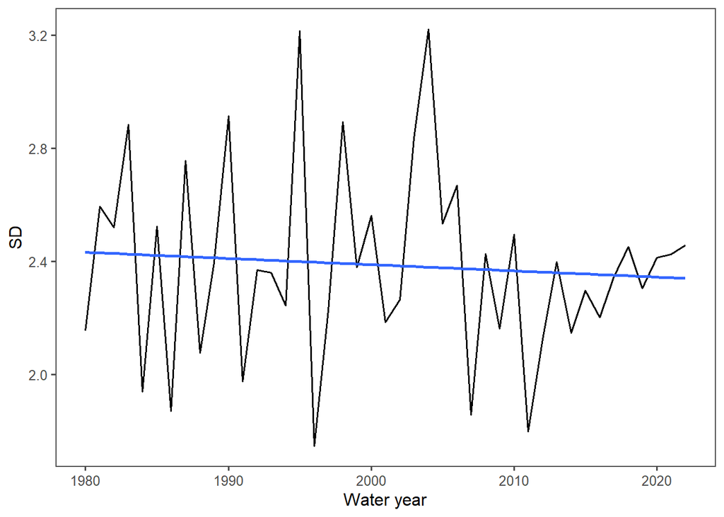

```r
ggplot(CO3005_standard_dev_all_summer, aes(x = waterYear, y = sd_2))+
  geom_line(size= 0.7) +
  theme_few() +
  geom_smooth(method = "lm", se=FALSE) +
  ylab('SD') +
  xlab('Water year')
```

Mann-Kendall & Sen’s Slope

Summer standard deviations.

```r
CO3005_sd_mk_summer <- mk.test(CO3005_standard_dev_all_summer$sd_2)
print(CO3005_sd_mk_summer)
```

```
##
##  Mann-Kendall trend test
##
## data:  CO3005_standard_dev_all_summer$sd_2
## z = -0.29303, n = 43, p-value = 0.7695
## alternative hypothesis: true S is not equal to 0
## sample estimates:
##             S          varS           tau
##  -29.00000000 9130.33333333   -0.03211517
```

```r
CO3005_sd_sens_summer <- sens.slope(CO3005_standard_dev_all_summer$sd_2)
print(CO3005_sd_sens_summer)
```

```
##
##  Sen's slope
##
## data:  CO3005_standard_dev_all_summer$sd_2
## z = -0.29303, n = 43, p-value = 0.7695
## alternative hypothesis: true z is not equal to 0
## 95 percent confidence interval:
##  -0.010132074  0.006955153
## sample estimates:
## Sen's slope
## -0.00188093
```

Winter temperature standard deviation

```r
CO3005_standard_dev_all_winter <- CO3005_standard_dev %>%
  filter(waterDay >= 32 & waterDay <= 182) %>% # this might be better off as daymonth rather than day of water year due to leap year
  group_by(waterYear) %>%
  mutate(nmbr = n())

CO3005_standard_dev_all_winter <- CO3005_standard_dev_all_winter %>%
  group_by(waterYear) %>%
  mutate(resid_mean = mean(residual)) %>%
  mutate(sd_1 = residual-resid_mean) %>%
  mutate(sd_2 = (((sum((sd_1)^2))/((nmbr-1))))^(0.5)) %>%
  distinct(sd_2, .keep_all = TRUE) %>%
   select(waterYear, sd_2)
CO3005_standard_dev_all_winter %>%
  kable(.,'html') %>%
  kable_styling() %>%
  scroll_box(width='250px',height='500px')
```

| waterYear | sd_2 |
| --- | --- |
| 1980 | 5.311169 |
| 1981 | 4.674171 |
| 1982 | 5.390883 |
| 1983 | 4.431281 |
| 1984 | 6.217399 |
| 1985 | 5.288151 |
| 1986 | 6.539813 |
| 1987 | 5.119993 |
| 1988 | 5.252471 |
| 1989 | 6.022333 |
| 1990 | 5.591939 |
| 1991 | 5.973460 |
| 1992 | 4.171284 |
| 1993 | 4.865627 |
| 1994 | 4.682615 |
| 1995 | 5.426112 |
| 1996 | 6.463789 |
| 1997 | 5.503674 |
| 1998 | 4.595218 |
| 1999 | 5.206445 |
| 2000 | 3.754223 |
| 2001 | 4.370990 |
| 2002 | 4.713033 |
| 2003 | 4.877020 |
| 2004 | 4.374715 |
| 2005 | 4.560324 |
| 2006 | 5.926068 |
| 2007 | 5.126742 |
| 2008 | 4.588725 |
| 2009 | 5.531805 |
| 2010 | 4.680834 |
| 2011 | 5.010796 |
| 2012 | 4.473630 |
| 2013 | 4.707202 |
| 2014 | 5.899271 |
| 2015 | 6.424867 |
| 2016 | 4.543851 |
| 2017 | 5.557833 |
| 2018 | 4.999853 |
| 2019 | 4.973721 |
| 2020 | 4.211180 |
| 2021 | 5.039000 |
| 2022 | 5.726720 |

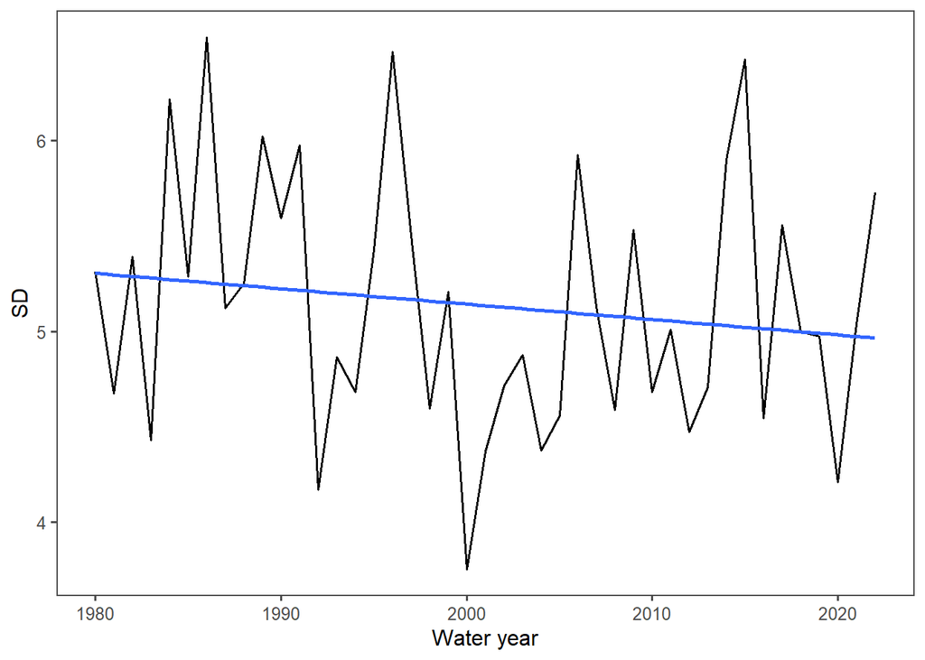

```r
ggplot(CO3005_standard_dev_all_winter, aes(x = waterYear, y = sd_2))+#, color = waterYear)) +
  geom_line(size= 0.7) +
  #geom_line(aes) +
  theme_few() +
  geom_smooth(method = "lm", se=FALSE) +
  ylab('SD') +
  xlab('Water year')
```

Mann-Kendall & Sen’s Slope

Winter standard deviations.

```r
CO3005_sd_mk_winter <- mk.test(CO3005_standard_dev_all_winter$sd_2)
print(CO3005_sd_mk_winter)
```

```
##
##  Mann-Kendall trend test
##
## data:  CO3005_standard_dev_all_winter$sd_2
## z = -0.94189, n = 43, p-value = 0.3463
## alternative hypothesis: true S is not equal to 0
## sample estimates:
##            S         varS          tau
##  -91.0000000 9130.3333333   -0.1007752
```

```r
CO3005_sd_sens_winter <- sens.slope(CO3005_standard_dev_all_winter$sd_2)
print(CO3005_sd_sens_winter)
```

```
##
##  Sen's slope
##
## data:  CO3005_standard_dev_all_winter$sd_2
## z = -0.94189, n = 43, p-value = 0.3463
## alternative hypothesis: true z is not equal to 0
## 95 percent confidence interval:
##  -0.025307857  0.009242702
## sample estimates:
##  Sen's slope
## -0.007602396
```

Spring and Fall temperature standard deviation

```r
CO3005_standard_dev_all_spring <- CO3005_standard_dev %>%
  filter(waterDay >= 183 & waterDay <= 243) %>% # this might be better off as daymonth rather than day of water year due to leap year
  group_by(waterYear) %>%
  mutate(nmbr = n())
CO3005_standard_dev_all_spring <- CO3005_standard_dev_all_spring %>%
  group_by(waterYear) %>%
  mutate(resid_mean = mean(residual)) %>%
  mutate(sd_1 = residual-resid_mean) %>%
  mutate(sd_2 = (((sum((sd_1)^2))/((nmbr-1))))^(0.5)) %>%
  distinct(sd_2, .keep_all = TRUE) %>%
   select(waterYear, sd_2)
CO3005_standard_dev_all_spring %>%
  kable(.,'html') %>%
  kable_styling() %>%
  scroll_box(width='250px',height='500px')
```

| waterYear | sd_2 |
| --- | --- |
| 1980 | 3.627139 |
| 1981 | 4.127264 |
| 1982 | 3.862977 |
| 1983 | 4.689489 |
| 1984 | 3.970855 |
| 1985 | 3.519699 |
| 1986 | 3.287118 |
| 1987 | 3.896178 |
| 1988 | 4.138164 |
| 1989 | 4.602575 |
| 1990 | 3.093581 |
| 1991 | 3.420259 |
| 1992 | 3.768894 |
| 1993 | 2.611483 |
| 1994 | 4.287460 |
| 1995 | 3.814871 |
| 1996 | 4.244031 |
| 1997 | 4.709460 |
| 1998 | 3.095772 |
| 1999 | 3.538398 |
| 2000 | 3.771736 |
| 2001 | 4.078028 |
| 2002 | 4.075485 |
| 2003 | 3.864663 |
| 2004 | 4.286649 |
| 2005 | 4.196446 |
| 2006 | 3.789688 |
| 2007 | 3.998652 |
| 2008 | 3.422290 |
| 2009 | 3.540402 |
| 2010 | 3.323889 |
| 2011 | 3.574703 |
| 2012 | 3.605389 |
| 2013 | 5.757444 |
| 2014 | 3.817116 |
| 2015 | 3.704015 |
| 2016 | 3.973316 |
| 2017 | 4.210290 |
| 2018 | 3.491115 |
| 2019 | 4.784674 |
| 2020 | 4.742375 |
| 2021 | 4.886790 |
| 2022 | 4.051516 |

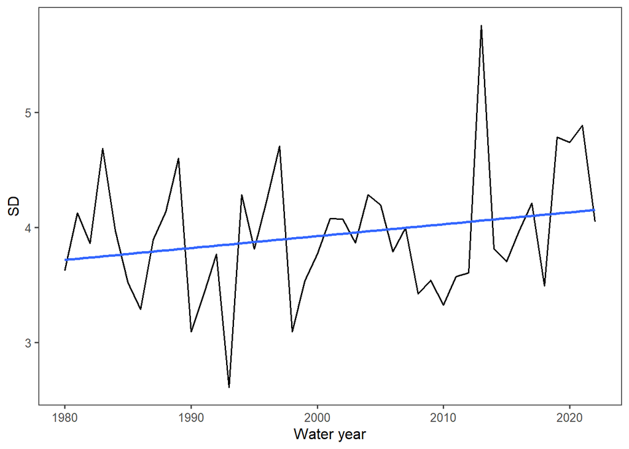

```r
ggplot(CO3005_standard_dev_all_spring, aes(x = waterYear, y = sd_2))+
  geom_line(size= 0.7) +
  theme_few() +
  geom_smooth(method = "lm", se=FALSE) +
  ylab('SD') +
  xlab('Water year')
```

Mann-Kendall & Sen’s Slope

Spring standard deviations.

```r
CO3005_sd_mk_spring <- mk.test(CO3005_standard_dev_all_spring$sd_2)
print(CO3005_sd_mk_spring)
```

```
##
##  Mann-Kendall trend test
##
## data:  CO3005_standard_dev_all_spring$sd_2
## z = 1.1512, n = 43, p-value = 0.2497
## alternative hypothesis: true S is not equal to 0
## sample estimates:
##            S         varS          tau
##  111.0000000 9130.3333333    0.1229236
```

```r
CO3005_sd_sens_spring <- sens.slope(CO3005_standard_dev_all_spring$sd_2)
print(CO3005_sd_sens_spring)
```

```
##
##  Sen's slope
##
## data:  CO3005_standard_dev_all_spring$sd_2
## z = 1.1512, n = 43, p-value = 0.2497
## alternative hypothesis: true z is not equal to 0
## 95 percent confidence interval:
##  -0.005542809  0.022685647
## sample estimates:
## Sen's slope
##  0.00688256
```

Fall temperature standard deviation

```r
CO3005_standard_dev_all_fall <- CO3005_standard_dev %>%
  filter(waterDay >= 336 | waterDay <= 31) %>% # this might be better off as daymonth rather than day of water year due to leap year
  group_by(waterYear) %>%
  mutate(nmbr = n())
# Nope. This did some weird stuff with twice the observations.
# CO3005_standard_dev_all_fall <- CO3005_standard_dev %>%
#   filter(daymonth >= "01-11" & daymonth <= "31-03") %>%
#   group_by(waterYear) %>%
#   mutate(nmbr = n())
CO3005_standard_dev_all_fall <- CO3005_standard_dev_all_fall %>%
  group_by(waterYear) %>%
  mutate(resid_mean = mean(residual)) %>%
  mutate(sd_1 = residual-resid_mean) %>%
  mutate(sd_2 = (((sum((sd_1)^2))/((nmbr-1))))^(0.5)) %>%
  distinct(sd_2, .keep_all = TRUE) %>%
   select(waterYear, sd_2)
CO3005_standard_dev_all_fall %>%
  kable(.,'html') %>%
  kable_styling() %>%
  scroll_box(width='250px',height='500px')
```

| waterYear | sd_2 |
| --- | --- |
| 1980 | 3.326390 |
| 1981 | 3.447107 |
| 1982 | 2.995481 |
| 1983 | 3.454035 |
| 1984 | 3.792770 |
| 1985 | 4.548853 |
| 1986 | 3.349194 |
| 1987 | 3.054082 |
| 1988 | 3.222957 |
| 1989 | 4.249975 |
| 1990 | 3.502137 |
| 1991 | 3.533642 |
| 1992 | 4.565582 |
| 1993 | 3.627515 |
| 1994 | 3.678478 |
| 1995 | 3.685885 |
| 1996 | 3.217835 |
| 1997 | 3.224346 |
| 1998 | 3.850160 |
| 1999 | 3.263153 |
| 2000 | 4.546258 |
| 2001 | 3.566700 |
| 2002 | 2.900918 |
| 2003 | 3.781220 |
| 2004 | 3.886406 |
| 2005 | 2.098685 |
| 2006 | 3.397984 |
| 2007 | 3.488638 |
| 2008 | 3.410098 |
| 2009 | 3.039582 |
| 2010 | 4.746716 |
| 2011 | 2.985778 |
| 2012 | 3.307573 |
| 2013 | 4.177628 |
| 2014 | 3.675494 |
| 2015 | 2.513405 |
| 2016 | 2.707078 |
| 2017 | 4.053224 |
| 2018 | 3.573829 |
| 2019 | 4.155111 |
| 2020 | 5.400904 |
| 2021 | 5.146163 |
| 2022 | 2.771812 |

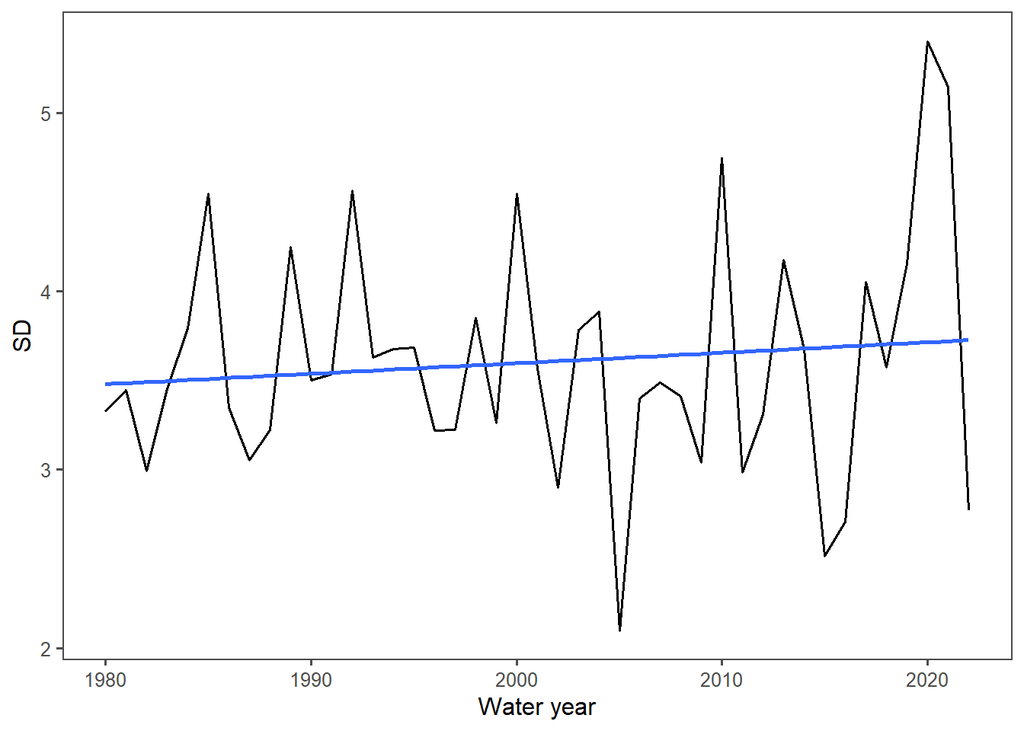

```r
ggplot(CO3005_standard_dev_all_fall, aes(x = waterYear, y = sd_2))+#, color = waterYear)) +
  geom_line(size= 0.7) +
  #geom_line(aes) +
  theme_few() +
  geom_smooth(method = "lm", se=FALSE) +
  ylab('SD') +
  xlab('Water year')
```

Mann-Kendall & Sen’s Slope

Fall standard deviations.

```r
CO3005_sd_mk_fall <- mk.test(CO3005_standard_dev_all_fall$sd_2)
print(CO3005_sd_mk_fall)
```

```
##
##  Mann-Kendall trend test
##
## data:  CO3005_standard_dev_all_fall$sd_2
## z = 0.5442, n = 43, p-value = 0.5863
## alternative hypothesis: true S is not equal to 0
## sample estimates:
##            S         varS          tau
## 5.300000e+01 9.130333e+03 5.869324e-02
```

```r
CO3005_sd_sens_fall <- sens.slope(CO3005_standard_dev_all_fall$sd_2)
print(CO3005_sd_sens_fall)
```

```
##
##  Sen's slope
##
## data:  CO3005_standard_dev_all_fall$sd_2
## z = 0.5442, n = 43, p-value = 0.5863
## alternative hypothesis: true z is not equal to 0
## 95 percent confidence interval:
##  -0.01346139  0.01977525
## sample estimates:
## Sen's slope
##  0.00597964
```